# Business Statistics Assessment IB94X0 2020-2021 #1

2092650

```r
options(width=100)
library(tidyverse)
library(scales)
library(emmeans)
library(gridExtra)
library(Hmisc)
```

# Data Dictionary

| Column Name | Explanation |
| --- | --- |
| Outlet_id | Unique store identifier |
| outlettype | Type of store - retailer operates three different kinds |
| sales_1 | Sales in each store for the last full reporting period prior to the trial being implemented |
| sales_2 | Sales in each store for the first full reporting period after the trial was implemented in select stores |
| intrial | Indicates whether the store outlet was selected to be in the trial (TRUE) or not (FALSE) |
| staff_turnover | Indicates the proportion of staff working at that outlet that left during the period the data covers |
| sales_change | The difference between sales_2 and sales_1 - also referred to as sales gain |
| percentage_diff | The percent difference between sales_2 and sales_1 |

# Question 1 Section 1

## Impact of Store Layout on Average Sales

The difference in sales gain controlling for ‘intrial’ can be seen below in Figure 1.

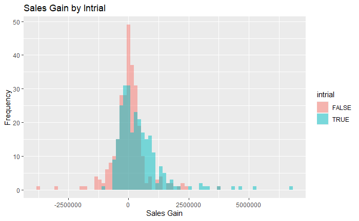

Figure 1: Sales Gain by Intrial

The mean sales gain for stores not participating in the trial is 18,642 GBP, 95% CI[ -78,661 – 115,946] GBP. The mean sales gain for stores participating in the trial is 426,893 GBP, 95% CI[327,214 – 526,572] GBP. The mean sales gain for stores not participating in the trial is 408,250 GBP less, 95% CI[-547,548 – -268,953] GBP, than stores participating in the trial. Stores participating in the trial have a higher mean sales gain compared to stores not participating in the trial.

The estimation approach data is visualized below in Figure 2 and 3.

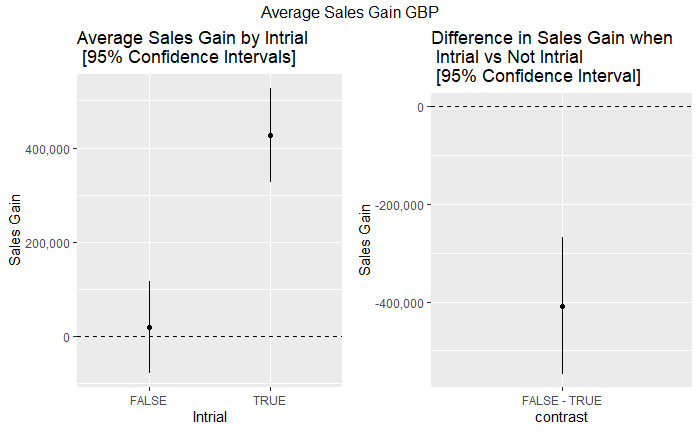

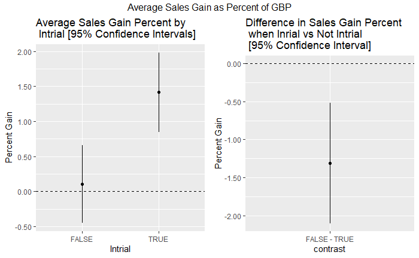

Figure 2: Average Sales Gain by ‘Intrail’ — Figure 3: Average Percent Gain by ‘Intrial’

## Optimal Dependent Varaible

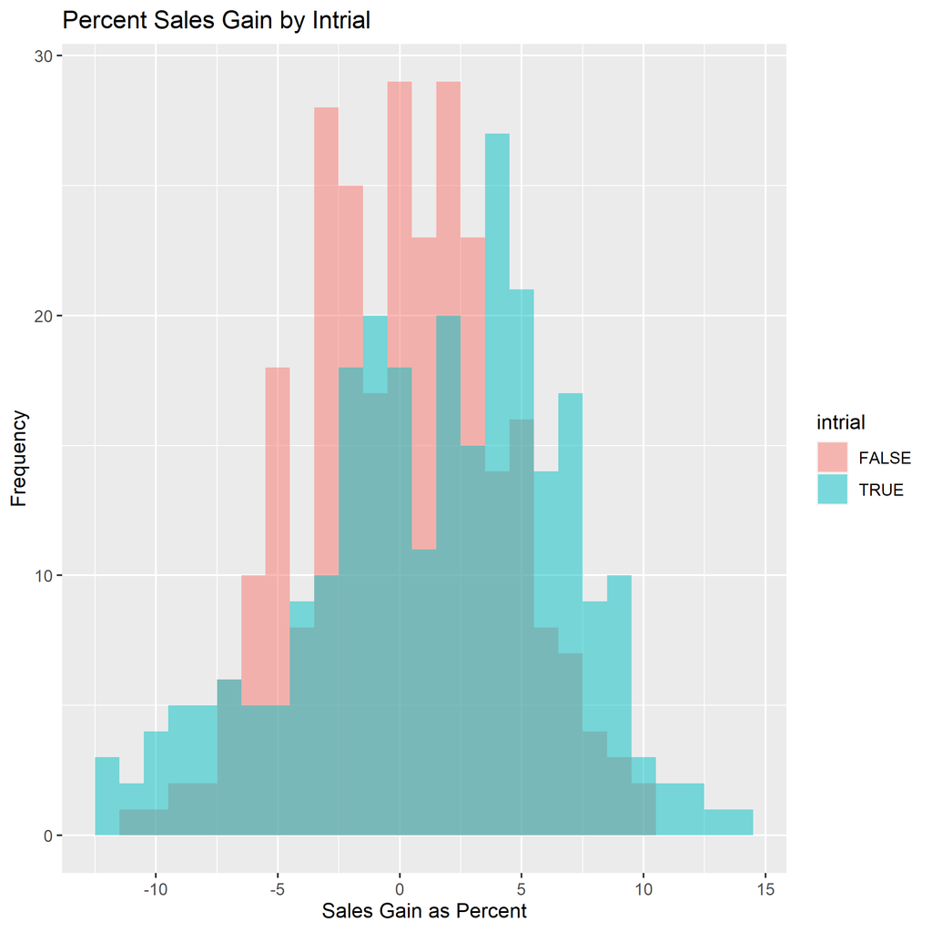

Figure 3: Percent Sales Gain by intrial

Although, it should be noted that ‘intrial’ can predict over two times the amount of variance in ‘sales_change’ than it can in ‘percentage_diff.’ Additionally, the P-value for ‘sales_change’ explained by ‘intrial’ is far more significant than ‘percentage_diff.’

### R-squared of Different Dependent Variables

| Model | R-squared |
| --- | --- |
| sales_change ~ intrial | 0.05638 |
| percentage_diff ~ intrial | 0.01755 |

### P-value for different Dependent Variables

| Model | P-value |
| --- | --- |
| sales_change ~ intrial | 1.898e-08 |
| percentage_diff ~ intrial | 0.001294 |

# Question 2 Section 1

## Impact of Outlet Type and Trial on Percent Sales Gain

In addition, the estimation approach confirms the NHT. Seen below in figure 4, the percent sales gain by outlet type and trial has been visualized. The confidence intervals for the stores which are not intrial overlap zero. It cannot be said that the percent sales gain for stores which are not intrial is different than zero. The estimated confidence intervals can be seen below.

| ‘outlettype’ and ‘intrial’ interaction | lower.CL | upper.CL | emmean |
| --- | --- | --- | --- |
| intrialTRUE:city_center_convenience | -5.387 | -3.586 | -4.4865 |
| intrialTRUE:outlettypecommunity_convenience | 3.002 | 4.323 | 3.6624 |
| intrialTRUE:outlettypesuperstore | 2.688 | 4.783 | 3.7355 |

| ‘outlettype’ and ‘intrial’ interaction | lower.CL | upper.CL | emmean |
| --- | --- | --- | --- |
| intrialFALSE:city_center_convenience | -0.908 | 0.724 | -0.0925 |
| intrialFALSE:outlettypecommunity_convenience | -0.494 | 0.836 | 0.1710 |
| intrialFALSE:outlettypesuperstore | -0.789 | 1.326 | 0.2682 |

In summary, ‘intrial’ and ‘outlettype’ both influence percent sales gain. Figure 4 shows that stores which are not intiral did not experience a change in percent sales gain. Additionally, ‘community_convenience’ and ‘superstore’ which are intrial experienced an increase in percent sales gain. In contrast, ‘city_centre_convenience’ saw a decline in percent sales gain for stores which were intrial.

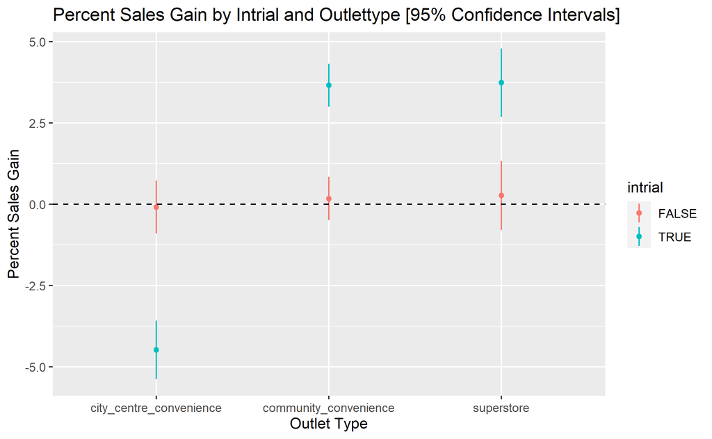

Figure 4: Percent Sales Gain by Outlet type

## Impact of Outlet Type, Trial, and Staff Turnover on Percent Sales Gain

Comparing models with and without ‘staff_turnover’ using ANOVA reveals it does not improve the model significantly, F(533) = 0.2894, p < 0.5908. The adjusted r-squares are also very similar for the two models.

| With and without ‘staff_turnover’ | Adj. R-squared |
| --- | --- |
| With ‘staff_turnover’ | 0.3073 |
| Without ‘staff_turnover’ | 0.3082 |

Additionally, the effects of ‘staff_turnover’ using the estimation approach can be seen below in Figure 5. From the chart, it is evident that ‘staff_turnover’ does not influence the sales gain at different outlet types.

[figure not shown]

Figure 5: Sales Gain by Outlet Type Controlling for ‘staff_turnover’

# Data Understanding

Reading in Data and Checking Integrity

```r
data <- read.csv("sales_data.txt", stringsAsFactors = TRUE)

#str(data)

#summary(data)
```

Checking Data for Outliers

Note: I believe the results would have been much different if outliers were removed, but because of the lack of information, I did not remove the majority of the potential outliers. For future analysis, I would recommend identifying the reasons for the potential outliers, and if they are identified as actual outliers, remove them.

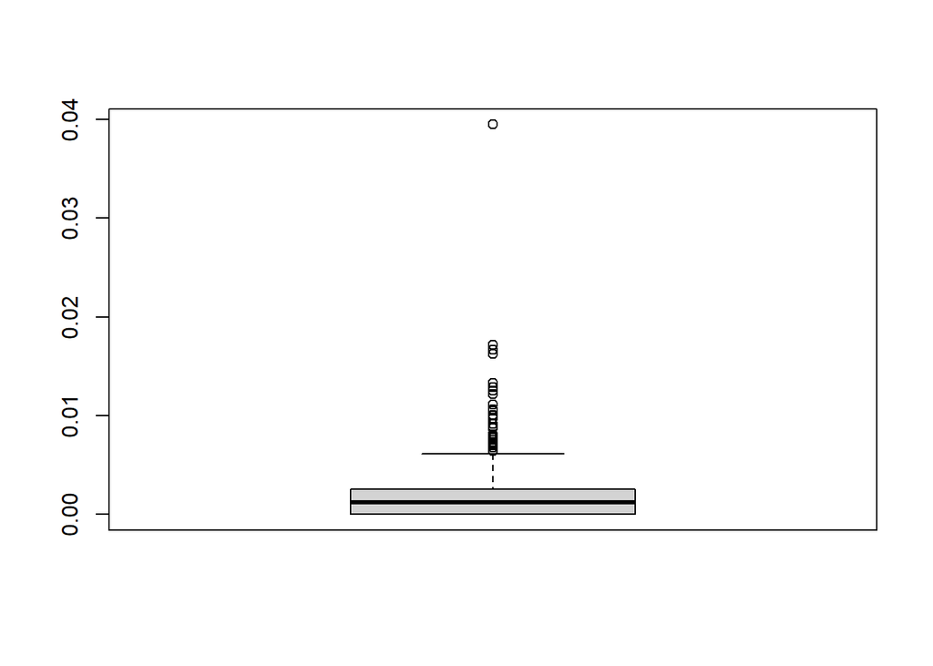

```r
boxplot(data$staff_turnover)
```

```r
#boxplot(data$sales_1)

#boxplot(data$sales_2)

data <- subset(data, staff_turnover < 0.039476) #Removing one extreme point which is very different from all other observations
```

Calculating Sales Gain in GPB and Percent

```r
data <- data %>% mutate(sales_change = sales_2 - sales_1, percentage_diff = ((sales_2 - sales_1)/sales_1)*100) # calculating difference in sales_1 and sales_2 in both in GBP and percentages
```

Histograms for ‘sales_change’ Controlling for ‘intrial’

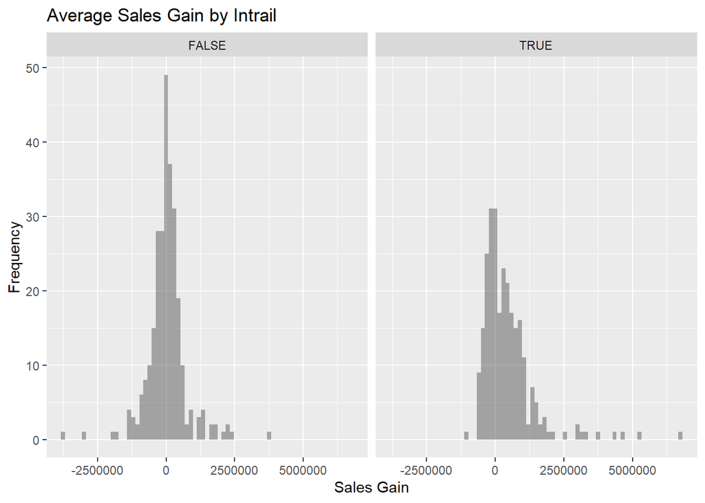

```r
ggplot(data, aes(x=sales_change)) + geom_histogram(position="identity", alpha=0.5, binwidth=150000) + facet_wrap(~intrial) + labs(title = "Average Sales Gain by Intrail", y = "Frequency", x = "Sales Gain")
```

Histograms of ‘sales_change’ Controlling for ‘initial’ and ‘outlettype’

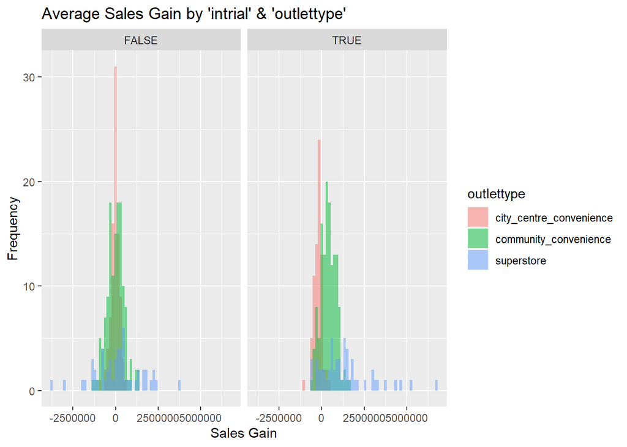

```r
ggplot(data, aes(x=sales_change, fill=outlettype)) + geom_histogram(position="identity", alpha=0.5, binwidth=150000) + facet_wrap(~intrial) + labs(title = "Average Sales Gain by 'intrial' & 'outlettype'", y = "Frequency", x = "Sales Gain")
```

# Question 1 Section 2

Linear Model of ‘sales_change’ Controlling for ‘intrial’

```r
# Creating linear model and finding estimated means and confidence intervals
lm1 <- lm(sales_change~intrial, data=data)
( lm1.emm <- emmeans(lm1, ~intrial)  )
```

```
##  intrial emmean    SE  df lower.CL upper.CL
##  FALSE    18642 49533 537   -78661   115946
##   TRUE   426893 50743 537   327214   526572
##
## Confidence level used: 0.95
```

```r
( lm1.contrast <- confint(pairs(lm1.emm)) )
```

```
##  contrast     estimate    SE  df lower.CL upper.CL
##  FALSE - TRUE  -408250 70911 537  -547548  -268953
##
## Confidence level used: 0.95
```

```r
#Using summary to for null hypothesis testing

summary(lm1)
```

```
##
## Call:
## lm(formula = sales_change ~ intrial, data = data)
##
## Residuals:
##      Min       1Q   Median       3Q      Max
## -3698217  -466624   -53193   269056  6341014
##
## Coefficients:
##             Estimate Std. Error t value Pr(>|t|)
## (Intercept)    18642      49533   0.376    0.707
## intrialTRUE   408250      70911   5.757 1.44e-08 ***
## ---
## Signif. codes:  0 '***' 0.001 '**' 0.01 '*' 0.05 '.' 0.1 ' ' 1
##
## Residual standard error: 822900 on 537 degrees of freedom
## Multiple R-squared:  0.05814,    Adjusted R-squared:  0.05638
## F-statistic: 33.15 on 1 and 537 DF,  p-value: 1.44e-08
```

```r
t.test(sales_change~intrial, data=data)
```

```
##
##  Welch Two Sample t-test
##
## data:  sales_change by intrial
## t = -5.7173, df = 483.08, p-value = 1.898e-08
## alternative hypothesis: true difference in means is not equal to 0
## 95 percent confidence interval:
##  -548555.3 -267945.5
## sample estimates:
## mean in group FALSE  mean in group TRUE
##            18642.45           426892.81
```

Linear Model of ‘percentage_diff’ Controlling for ‘intrial’

```r
# Creating linear model and finding estimated means and confidence intervals
lm2 <- lm(percentage_diff~intrial, data=data)
( lm2.emm <- emmeans(lm2, ~intrial)  )
```

```
##  intrial emmean    SE  df lower.CL upper.CL
##  FALSE    0.105 0.281 537   -0.447    0.657
##   TRUE    1.416 0.288 537    0.850    1.981
##
## Confidence level used: 0.95
```

```r
( lm2.contrast <- confint(pairs(lm2.emm)) )
```

```
##  contrast     estimate    SE  df lower.CL upper.CL
##  FALSE - TRUE    -1.31 0.402 537     -2.1    -0.52
##
## Confidence level used: 0.95
```

```r
#Using summary to for null hypothesis testing
summary(lm2)
```

```
##
## Call:
## lm(formula = percentage_diff ~ intrial, data = data)
##
## Residuals:
##      Min       1Q   Median       3Q      Max
## -13.7504  -2.9778   0.2945   3.2668  12.1563
##
## Coefficients:
##             Estimate Std. Error t value Pr(>|t|)
## (Intercept)   0.1047     0.2811   0.373  0.70966
## intrialTRUE   1.3109     0.4024   3.258  0.00119 **
## ---
## Signif. codes:  0 '***' 0.001 '**' 0.01 '*' 0.05 '.' 0.1 ' ' 1
##
## Residual standard error: 4.67 on 537 degrees of freedom
## Multiple R-squared:  0.01938,    Adjusted R-squared:  0.01755
## F-statistic: 10.61 on 1 and 537 DF,  p-value: 0.001195
```

```r
t.test(percentage_diff~intrial, data=data)
```

```
##
##  Welch Two Sample t-test
##
## data:  percentage_diff by intrial
## t = -3.2362, df = 487.33, p-value = 0.001294
## alternative hypothesis: true difference in means is not equal to 0
## 95 percent confidence interval:
##  -2.1067510 -0.5149817
## sample estimates:
## mean in group FALSE  mean in group TRUE
##           0.1047072           1.4155735
```

Histogram of Sales Gain and Percentage Diff Controlling for ‘initial’

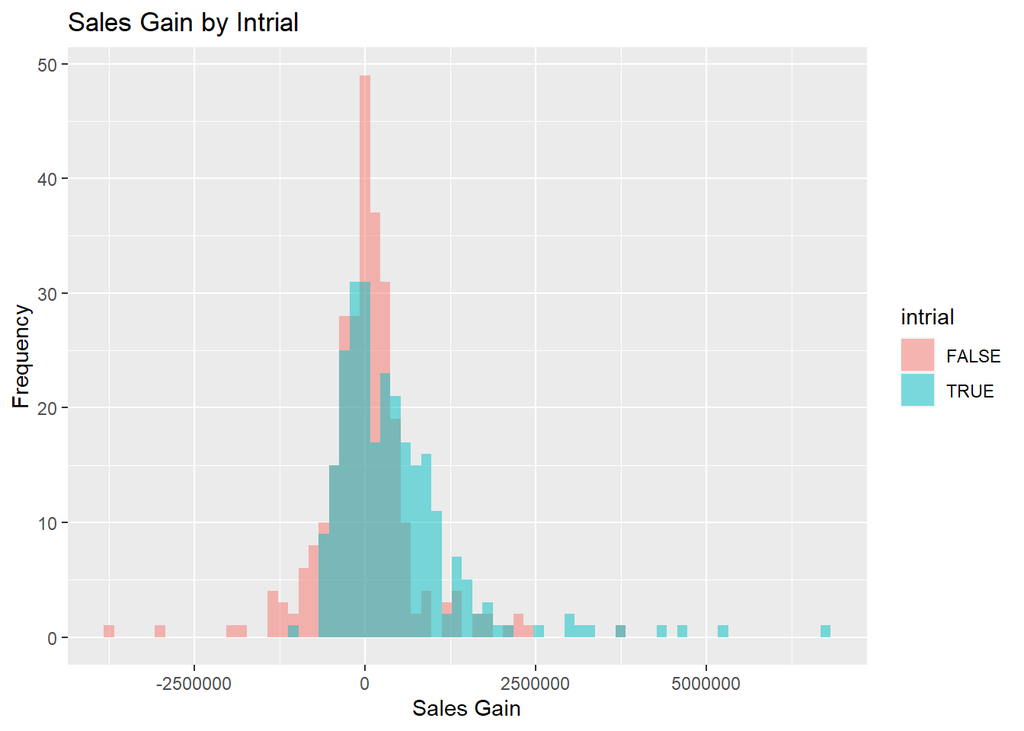

```r
#Plot for sales_change
ggplot(data, aes(x=sales_change, fill=intrial)) + geom_histogram(position="identity", alpha=0.5, binwidth=150000) + labs(title = "Sales Gain by Intrial", x = "Sales Gain", y = "Frequency")
```

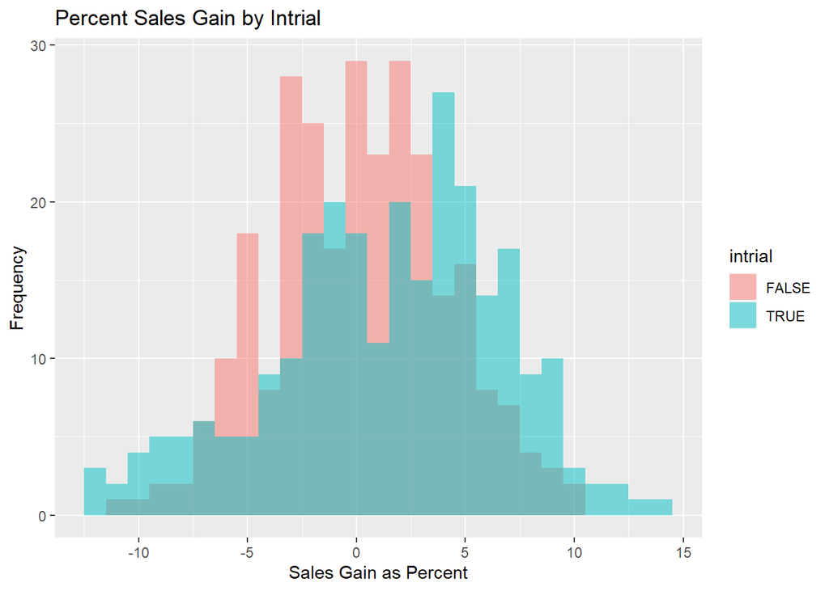

```r
#Plot for percentage_diff
ggplot(data, aes(x=percentage_diff, fill=intrial)) + geom_histogram(position="identity", alpha=0.5, binwidth=1) + labs(title = "Percent Sales Gain by Intrial", x = "Sales Gain as Percent", y = "Frequency")
```

```r
#ggsave("percent_sales_gain_by_intial.png")
```

Plotting Estimation Approach for ‘sales_change’ and ‘percentage_diff’ Controlling for ‘intrial’

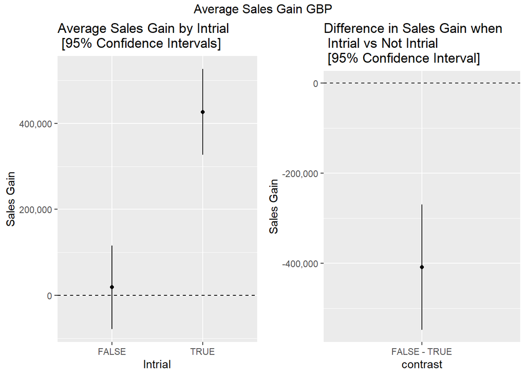

```r
#Sales growth diff using estimated means and confidence intervals from lm1
grid.arrange(
ggplot(summary(lm1.emm), mapping = aes(x = intrial, y = emmean, ymin = lower.CL, ymax = upper.CL)) + geom_point()+ geom_linerange() + geom_hline(yintercept = 0, linetype = 2) + labs(x = "Intrial", y = "Sales Gain", title = "Average Sales Gain by Intrial \n [95% Confidence Intervals]") + scale_y_continuous(labels = comma),

ggplot(lm1.contrast, mapping = aes(x = contrast, y = estimate, ymin = lower.CL, ymax = upper.CL)) + geom_point() + geom_linerange() + geom_hline(yintercept = 0, linetype = 2) + labs(y = "Sales Gain", title = "Difference in Sales Gain when \n Intrial vs Not Intrial \n [95% Confidence Interval]") + scale_y_continuous(labels = comma)
, ncol = 2, top = "Average Sales Gain GBP")
```

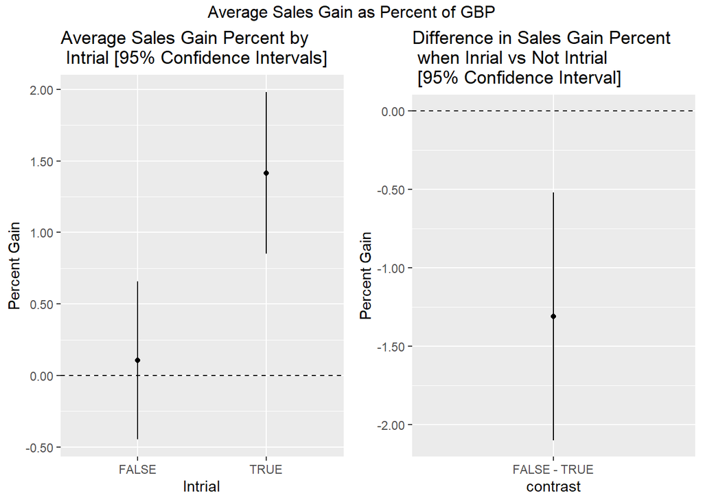

```r
#Percent growth diff using estimated means and confidence intervals from lm2
grid.arrange(
ggplot(summary(lm2.emm), mapping = aes(x = intrial, y = emmean, ymin = lower.CL, ymax = upper.CL)) + geom_point() + geom_linerange() + geom_hline(yintercept = 0, linetype = 2) + labs(x = "Intrial", y = "Percent Gain", title = "Average Sales Gain Percent by  \n Intrial [95% Confidence Intervals]") + scale_y_continuous(labels = comma),

ggplot(lm2.contrast, mapping = aes(x = contrast, y = estimate, ymin = lower.CL, ymax = upper.CL)) + geom_point() + geom_linerange() + geom_hline(yintercept = 0, linetype = 2) + labs(y = "Percent Gain", title = "Difference in Sales Gain Percent  \n when Inrial vs Not Intrial \n [95% Confidence Interval]") + scale_y_continuous(labels = comma)
, ncol = 2, top = "Average Sales Gain as Percent of GBP")
```

# Question 2 Section 2

```r
# Creating linear model and finding estimated means and confidence intervals
lm3 <- lm(percentage_diff~intrial * outlettype, data=data)
( lm3.emm <- emmeans(lm3, ~intrial * outlettype)  )
```

```
##  intrial outlettype               emmean    SE  df lower.CL upper.CL
##  FALSE   city_centre_convenience -0.0925 0.415 533   -0.908    0.724
##   TRUE   city_centre_convenience -4.4865 0.459 533   -5.387   -3.586
##  FALSE   community_convenience    0.1710 0.339 533   -0.494    0.836
##   TRUE   community_convenience    3.6624 0.336 533    3.002    4.323
##  FALSE   superstore               0.2682 0.538 533   -0.789    1.326
##   TRUE   superstore               3.7355 0.533 533    2.688    4.783
##
## Confidence level used: 0.95
```

```r
( lm3.contrast <- confint(pairs(lm3.emm)) )
```

```
##  contrast                                                     estimate    SE  df lower.CL upper.CL
##  FALSE city_centre_convenience - TRUE city_centre_convenience   4.3940 0.619 533     2.62     6.16
##  FALSE city_centre_convenience - FALSE community_convenience   -0.2635 0.536 533    -1.80     1.27
##  FALSE city_centre_convenience - TRUE community_convenience    -3.7549 0.534 533    -5.28    -2.23
##  FALSE city_centre_convenience - FALSE superstore              -0.3607 0.680 533    -2.31     1.58
##  FALSE city_centre_convenience - TRUE superstore               -3.8280 0.676 533    -5.76    -1.89
##  TRUE city_centre_convenience - FALSE community_convenience    -4.6575 0.570 533    -6.29    -3.03
##  TRUE city_centre_convenience - TRUE community_convenience     -8.1489 0.569 533    -9.78    -6.52
##  TRUE city_centre_convenience - FALSE superstore               -4.7547 0.707 533    -6.78    -2.73
##  TRUE city_centre_convenience - TRUE superstore                -8.2220 0.703 533   -10.23    -6.21
##  FALSE community_convenience - TRUE community_convenience      -3.4914 0.477 533    -4.86    -2.13
##  FALSE community_convenience - FALSE superstore                -0.0972 0.636 533    -1.92     1.72
##  FALSE community_convenience - TRUE superstore                 -3.5645 0.632 533    -5.37    -1.76
##  TRUE community_convenience - FALSE superstore                  3.3942 0.635 533     1.58     5.21
##  TRUE community_convenience - TRUE superstore                  -0.0731 0.630 533    -1.88     1.73
##  FALSE superstore - TRUE superstore                            -3.4673 0.758 533    -5.63    -1.30
##
## Confidence level used: 0.95
## Conf-level adjustment: tukey method for comparing a family of 6 estimates
```

```r
#Using anova and summary to for null hypothesis testing
summary(lm3)
```

```
##
## Call:
## lm(formula = percentage_diff ~ intrial * outlettype, data = data)
##
## Residuals:
##      Min       1Q   Median       3Q      Max
## -11.1389  -2.8173   0.0439   2.7433   9.9502
##
## Coefficients:
##                                             Estimate Std. Error t value Pr(>|t|)
## (Intercept)                                 -0.09247    0.41538  -0.223    0.824
## intrialTRUE                                 -4.39401    0.61879  -7.101 3.98e-12 ***
## outlettypecommunity_convenience              0.26347    0.53585   0.492    0.623
## outlettypesuperstore                         0.36068    0.67991   0.530    0.596
## intrialTRUE:outlettypecommunity_convenience  7.88545    0.78128  10.093  < 2e-16 ***
## intrialTRUE:outlettypesuperstore             7.86130    0.97826   8.036 6.01e-15 ***
## ---
## Signif. codes:  0 '***' 0.001 '**' 0.01 '*' 0.05 '.' 0.1 ' ' 1
##
## Residual standard error: 3.919 on 533 degrees of freedom
## Multiple R-squared:  0.3146, Adjusted R-squared:  0.3082
## F-statistic: 48.93 on 5 and 533 DF,  p-value: < 2.2e-16
```

```r
anova(lm3)
```

```
## Analysis of Variance Table
##
## Response: percentage_diff
##                     Df Sum Sq Mean Sq F value    Pr(>F)
## intrial              1  231.4  231.42  15.070 0.0001166 ***
## outlettype           2 1779.3  889.64  57.934 < 2.2e-16 ***
## intrial:outlettype   2 1746.3  873.15  56.860 < 2.2e-16 ***
## Residuals          533 8184.8   15.36
## ---
## Signif. codes:  0 '***' 0.001 '**' 0.01 '*' 0.05 '.' 0.1 ' ' 1
```

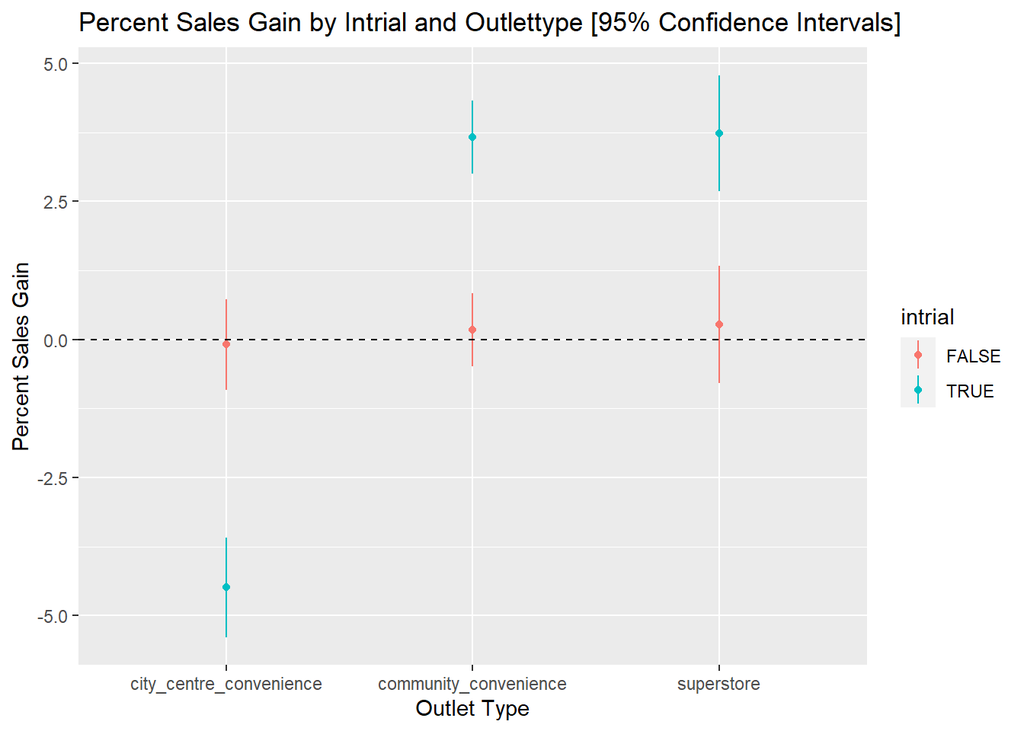

```r
ggplot(summary(lm3.emm), mapping = aes(x = outlettype, y = emmean, ymin = lower.CL, ymax = upper.CL, color = intrial)) + geom_point() + geom_linerange() + geom_hline(yintercept = 0, linetype = 2) + labs(x = "Outlet Type", y = "Percent Sales Gain", title = "Percent Sales Gain by Intrial and Outlettype [95% Confidence Intervals]") + scale_y_continuous(labels = comma) #adds commas to y axis scale
```

```r
#ggsave("percent_sales_gain_by_intrial_and_outlettype.png", )
```

Linear Model Examining the Effect of ‘staff_turnover’ and ‘intial’ on Sales Gain - Make graph with estimation approach

```r
# Creating linear model and finding estimated means and confidence intervals
lm4 <- lm(percentage_diff~intrial * outlettype + staff_turnover, data=data)
( lm4.emm <- emmeans(lm4, ~intrial * outlettype + staff_turnover)  )
```

```
##  intrial outlettype              staff_turnover  emmean    SE  df lower.CL upper.CL
##  FALSE   city_centre_convenience        0.00192 -0.0796 0.416 532   -0.897    0.738
##   TRUE   city_centre_convenience        0.00192 -4.5097 0.461 532   -5.415   -3.604
##  FALSE   community_convenience          0.00192  0.1975 0.342 532   -0.475    0.870
##   TRUE   community_convenience          0.00192  3.6427 0.338 532    2.978    4.307
##  FALSE   superstore                     0.00192  0.2852 0.540 532   -0.775    1.345
##   TRUE   superstore                     0.00192  3.7128 0.535 532    2.661    4.764
##
## Confidence level used: 0.95
```

```r
( lm4.contrast <- confint(pairs(lm4.emm)) )
```

```
##  contrast
##  FALSE city_centre_convenience 0.00192374323198243 - TRUE city_centre_convenience 0.00192374323198243
##  FALSE city_centre_convenience 0.00192374323198243 - FALSE community_convenience 0.00192374323198243
##  FALSE city_centre_convenience 0.00192374323198243 - TRUE community_convenience 0.00192374323198243
##  FALSE city_centre_convenience 0.00192374323198243 - FALSE superstore 0.00192374323198243
##  FALSE city_centre_convenience 0.00192374323198243 - TRUE superstore 0.00192374323198243
##  TRUE city_centre_convenience 0.00192374323198243 - FALSE community_convenience 0.00192374323198243
##  TRUE city_centre_convenience 0.00192374323198243 - TRUE community_convenience 0.00192374323198243
##  TRUE city_centre_convenience 0.00192374323198243 - FALSE superstore 0.00192374323198243
##  TRUE city_centre_convenience 0.00192374323198243 - TRUE superstore 0.00192374323198243
##  FALSE community_convenience 0.00192374323198243 - TRUE community_convenience 0.00192374323198243
##  FALSE community_convenience 0.00192374323198243 - FALSE superstore 0.00192374323198243
##  FALSE community_convenience 0.00192374323198243 - TRUE superstore 0.00192374323198243
##  TRUE community_convenience 0.00192374323198243 - FALSE superstore 0.00192374323198243
##  TRUE community_convenience 0.00192374323198243 - TRUE superstore 0.00192374323198243
##  FALSE superstore 0.00192374323198243 - TRUE superstore 0.00192374323198243
##  estimate    SE  df lower.CL upper.CL
##    4.4302 0.623 532     2.65     6.21
##   -0.2771 0.537 532    -1.81     1.26
##   -3.7223 0.538 532    -5.26    -2.18
##   -0.3648 0.680 532    -2.31     1.58
##   -3.7923 0.680 532    -5.74    -1.85
##   -4.7073 0.578 532    -6.36    -3.05
##   -8.1525 0.569 532    -9.78    -6.53
##   -4.7949 0.712 532    -6.83    -2.76
##   -8.2225 0.704 532   -10.24    -6.21
##   -3.4452 0.485 532    -4.83    -2.06
##   -0.0877 0.637 532    -1.91     1.73
##   -3.5152 0.639 532    -5.34    -1.69
##    3.3575 0.639 532     1.53     5.18
##   -0.0700 0.631 532    -1.87     1.73
##   -3.4276 0.762 532    -5.61    -1.25
##
## Confidence level used: 0.95
## Conf-level adjustment: tukey method for comparing a family of 6 estimates
```

```r
#Using summary to for null hypothesis testing
summary(lm4)
```

```
##
## Call:
## lm(formula = percentage_diff ~ intrial * outlettype + staff_turnover,
##     data = data)
##
## Residuals:
##      Min       1Q   Median       3Q      Max
## -11.2155  -2.8145   0.0887   2.7263   9.9098
##
## Coefficients:
##                                              Estimate Std. Error t value Pr(>|t|)
## (Intercept)                                  -0.01589    0.43936  -0.036    0.971
## intrialTRUE                                  -4.43017    0.62284  -7.113 3.69e-12 ***
## outlettypecommunity_convenience               0.27711    0.53681   0.516    0.606
## outlettypesuperstore                          0.36476    0.68040   0.536    0.592
## staff_turnover                              -33.10378   61.53341  -0.538    0.591
## intrialTRUE:outlettypecommunity_convenience   7.87536    0.78203  10.070  < 2e-16 ***
## intrialTRUE:outlettypesuperstore              7.85773    0.97894   8.027 6.45e-15 ***
## ---
## Signif. codes:  0 '***' 0.001 '**' 0.01 '*' 0.05 '.' 0.1 ' ' 1
##
## Residual standard error: 3.921 on 532 degrees of freedom
## Multiple R-squared:  0.315,  Adjusted R-squared:  0.3073
## F-statistic: 40.77 on 6 and 532 DF,  p-value: < 2.2e-16
```

```r
anova(lm4)
```

```
## Analysis of Variance Table
##
## Response: percentage_diff
##                     Df Sum Sq Mean Sq F value    Pr(>F)
## intrial              1  231.4  231.42 15.0500 0.0001178 ***
## outlettype           2 1779.3  889.64 57.8571 < 2.2e-16 ***
## staff_turnover       1    8.9    8.85  0.5758 0.4483012
## intrial:outlettype   2 1741.9  870.95 56.6413 < 2.2e-16 ***
## Residuals          532 8180.3   15.38
## ---
## Signif. codes:  0 '***' 0.001 '**' 0.01 '*' 0.05 '.' 0.1 ' ' 1
```

Comparing model with staff_turnover vs without

```r
anova(lm3, lm4)
```

```
## Analysis of Variance Table
##
## Model 1: percentage_diff ~ intrial * outlettype
## Model 2: percentage_diff ~ intrial * outlettype + staff_turnover
##   Res.Df    RSS Df Sum of Sq      F Pr(>F)
## 1    533 8184.8
## 2    532 8180.3  1    4.4503 0.2894 0.5908
```

Plotting Estimation Approach to Show Effects of ‘staff_turnover’

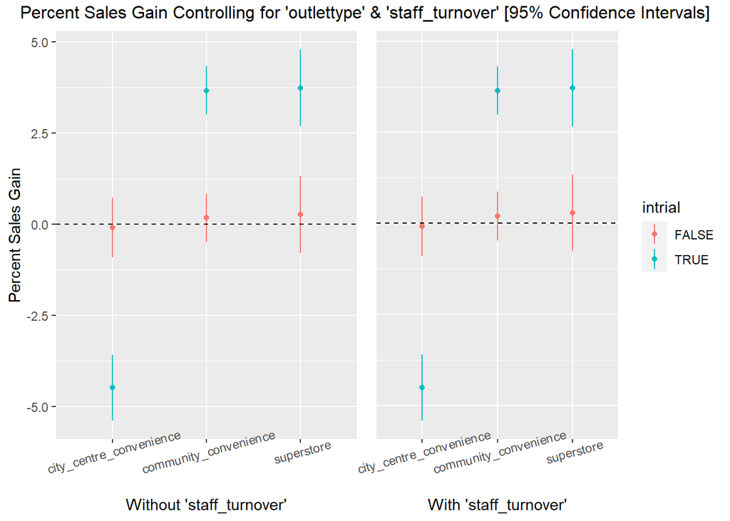

```r
g <- grid.arrange(

ggplot(summary(lm3.emm), mapping = aes(x = outlettype, y = emmean, ymin = lower.CL, ymax = upper.CL, color = intrial)) + geom_point()+ geom_linerange() + geom_hline(yintercept = 0, linetype = 2) + labs(x = "Without 'staff_turnover'", y = "Percent Sales Gain") + scale_y_continuous(labels = comma) + theme(legend.position = "none", axis.text.x = element_text(angle = 15)),

ggplot(summary(lm4.emm), mapping = aes(x = outlettype, y = emmean, ymin = lower.CL, ymax = upper.CL, color = intrial)) + geom_point()+ geom_linerange() + geom_hline(yintercept = 0, linetype = 2) + labs(x = "With 'staff_turnover'", y = "Percent Sales Gain") + scale_y_continuous(labels = comma)+ theme(axis.title.y=element_blank(), axis.text.y=element_blank(), axis.ticks.y=element_blank(), axis.text.x = element_text(angle = 15)),

ncol = 2, top = "Percent Sales Gain Controlling for 'outlettype' & 'staff_turnover' [95% Confidence Intervals]")
```

```r
#ggsave("percent sales gain controlling for outlettype and staff turnover.png", g)
```

# References

Frost, J., 2021. How To Interpret R-Squared In Regression Analysis - Statistics By Jim. [online] Statistics By Jim. Available at: https://statisticsbyjim.com/regression/interpret-r-squared-regression/ [Accessed 24 January 2021].

Sthda.com. 2021. Correlation Test Between Two Variables In R - Easy Guides - Wiki - STHDA. [online] Available at: http://www.sthda.com/english/wiki/wiki.php?id_contents=7312 [Accessed 24 January 2021].

Medium. 2021. An Overview Of Correlation Measures Between Categorical And Continuous Variables. [online] Available at: https://medium.com/@outside2SDs/an-overview-of-correlation-measures-between-categorical-and-continuous-variables-4c7f85610365 [Accessed 24 January 2021].

```r
citation("tidyverse")
```

```
##
##   Wickham et al., (2019). Welcome to the tidyverse. Journal of Open Source Software,
##   4(43), 1686, https://doi.org/10.21105/joss.01686
##
## A BibTeX entry for LaTeX users is
##
##   @Article{,
##     title = {Welcome to the {tidyverse}},
##     author = {Hadley Wickham and Mara Averick and Jennifer Bryan and Winston Chang and Lucy D'Agostino McGowan and Romain François and Garrett Grolemund and Alex Hayes and Lionel Henry and Jim Hester and Max Kuhn and Thomas Lin Pedersen and Evan Miller and Stephan Milton Bache and Kirill Müller a…
##     year = {2019},
##     journal = {Journal of Open Source Software},
##     volume = {4},
##     number = {43},
##     pages = {1686},
##     doi = {10.21105/joss.01686},
##   }
```

```r
citation("scales")
```

```
##
##
##   Hadley Wickham and Dana Seidel (2020). scales: Scale Functions for Visualization. R
##   package version 1.1.1. https://CRAN.R-project.org/package=scales
##
## A BibTeX entry for LaTeX users is
##
##   @Manual{,
##     title = {scales: Scale Functions for Visualization},
##     author = {Hadley Wickham and Dana Seidel},
##     year = {2020},
##     note = {R package version 1.1.1},
##     url = {https://CRAN.R-project.org/package=scales},
##   }
```

```r
citation("emmeans")
```

```
##
##
##   Russell V. Lenth (2021). emmeans: Estimated Marginal Means, aka Least-Squares Means. R
##   package version 1.6.2-1. https://CRAN.R-project.org/package=emmeans
##
## A BibTeX entry for LaTeX users is
##
##   @Manual{,
##     title = {emmeans: Estimated Marginal Means, aka Least-Squares Means},
##     author = {Russell V. Lenth},
##     year = {2021},
##     note = {R package version 1.6.2-1},
##     url = {https://CRAN.R-project.org/package=emmeans},
##   }
```

```r
citation("gridExtra")
```

```
##
##
##   Baptiste Auguie (2017). gridExtra: Miscellaneous Functions for "Grid" Graphics. R
##   package version 2.3. https://CRAN.R-project.org/package=gridExtra
##
## A BibTeX entry for LaTeX users is
##
##   @Manual{,
##     title = {gridExtra: Miscellaneous Functions for "Grid" Graphics},
##     author = {Baptiste Auguie},
##     year = {2017},
##     note = {R package version 2.3},
##     url = {https://CRAN.R-project.org/package=gridExtra},
##   }
```

```r
citation("Hmisc")
```

```
##
##
##   Frank E Harrell Jr, with contributions from Charles Dupont and many others. (2021).
##   Hmisc: Harrell Miscellaneous. R package version 4.5-0.
##   https://CRAN.R-project.org/package=Hmisc
##
## A BibTeX entry for LaTeX users is
##
##   @Manual{,
##     title = {Hmisc: Harrell Miscellaneous},
##     author = {Frank E {Harrell Jr} and with contributions from Charles Dupont and many others.},
##     year = {2021},
##     note = {R package version 4.5-0},
##     url = {https://CRAN.R-project.org/package=Hmisc},
##   }
##
## ATTENTION: This citation information has been auto-generated from the package DESCRIPTION
## file and may need manual editing, see 'help("citation")'.
```